# Lecture 2-1: Basic Data Types

# Agenda

- Built-in data types
- Built-in functions and operators
- First data structures: Vectors and arrays

# Data Type

- **Logical**: TRUE, FALSE, NA
- **Numeric**: can be one of two:
  - *Double*: 13.8, -0.5, Inf
  - *Integers*: 2L, 34L, 0L, -1L
- **Complex**: 3 + 2i
- **Character**: ‘abc’, “good”, “TRUE”, ‘12.3’
- **Raw**: “Hello” is stored as 48 65 6c 6c 6f

Examples:

```r
v1 <- TRUE
class(v1)
```

```
## [1] "logical"
```

```r
v2 <- 23.5
class(v2)
```

```
## [1] "numeric"
```

```r
v3 <- 2L
class(v3)
```

```
## [1] "integer"
```

```r
v4 <- 2+5i
class(v4)
```

```
## [1] "complex"
```

```r
v5 <- "Good Morning"
class(v5)
```

```
## [1] "character"
```

```r
v6 <- charToRaw("Hello")
v6
```

```
## [1] 48 65 6c 6c 6f
```

```r
class(v6)
```

```
## [1] "raw"
```

# Operators

- Unary `-` for arithmetic negation, `!` for Boolean.
- Binary usual arithmetic operators, plus ones for modulo and integer division; take two numbers and give a number.

Example:

```r
7 + 5
```

```
## [1] 12
```

```r
7 - 5
```

```
## [1] 2
```

```r
7 * 5
```

```
## [1] 35
```

```r
7 ^ 5
```

```
## [1] 16807
```

```r
7 / 5
```

```
## [1] 1.4
```

```r
7 %% 5
```

```
## [1] 2
```

```r
7 %/% 5
```

```
## [1] 1
```

Operators are, in essence, functions. In fact, there is an equivalent notation for each operator which highlights this:

```r
"+"(5, 7)
```

```
## [1] 12
```

# Number comparisons

**Comparisons** are also binary operators; they take two objects, like numbers, and give a Boolean:

```r
7 > 5
```

```
## [1] TRUE
```

```r
7 < 5
```

```
## [1] FALSE
```

```r
7 >= 7
```

```
## [1] TRUE
```

```r
7 == 5
```

```
## [1] FALSE
```

```r
7 != 5
```

```
## [1] TRUE
```

Comparison operators are also functions:

```r
">="(7, 5)
```

```
## [1] TRUE
```

# Boolean operators

Basically “and” and “or”:

```r
(5 > 7) & (6 * 7 == 42)
```

```
## [1] FALSE
```

```r
(5 > 7) | (6 * 7 == 42)
```

```
## [1] TRUE
```

(We will see special doubled forms, `&&` and `||`, later.)

# More types

`typeof()` function returns the type

`is.`*foo*`()` functions return Booleans for whether the argument is of type *foo*.

`as.`*foo*`()` (tries to) “cast” its argument to type *foo* to translate it sensibly into a *foo*-type value.

Examples:

```r
typeof(7)
```

```
## [1] "double"
```

```r
is.numeric(7)
```

```
## [1] TRUE
```

```r
is.double(7)
```

```
## [1] TRUE
```

```r
is.integer(7)
```

```
## [1] FALSE
```

```r
typeof(7L)
```

```
## [1] "integer"
```

```r
is.numeric(7L)
```

```
## [1] TRUE
```

```r
is.double(7L)
```

```
## [1] FALSE
```

```r
is.integer(7L)
```

```
## [1] TRUE
```

```r
is.na(7)
```

```
## [1] FALSE
```

```r
is.na(0/0)
```

```
## [1] TRUE
```

```r
is.nan(0/0)
```

```
## [1] TRUE
```

```r
is.character(7)
```

```
## [1] FALSE
```

```r
is.character("7")
```

```
## [1] TRUE
```

```r
is.character("seven")
```

```
## [1] TRUE
```

```r
is.na("seven")
```

```
## [1] FALSE
```

```r
as.character(5 / 6)
```

```
## [1] "0.833333333333333"
```

```r
as.numeric(as.character(5 / 6))
```

```
## [1] 0.8333333
```

# Variables

We’ve already seen that we can assign values to variables.

```r
a = 5
```

There are also some important built in variables in R:

```r
T
```

```
## [1] TRUE
```

`T` is a global variable. However, as tempting it may be to use it, see what happens:

```r
T = "Peace!"
T
```

```
## [1] "Peace!"
```

```r
T == TRUE
```

```
## [1] FALSE
```

Similarly, `pi`. Variables can be arguments to functions or operators, just like constants:

```r
cos(pi)
```

```
## [1] -1
```

```r
pi = 0
cos(pi)
```

```
## [1] 1
```

Note: generally speaking R functions does not use pointers (Indeed, many functions and objects in R use C in the background and utilize C pointers, but pointers are not used at the high-level)

# Workspace

What names have you defined values for?

```r
ls()
```

```
## [1] "a"  "pi" "T"  "v1" "v2" "v3" "v4" "v5" "v6"
```

Getting rid of a defined variable:

```r
rm("pi")
ls()
```

```
## [1] "a"  "T"  "v1" "v2" "v3" "v4" "v5" "v6"
```

Define a function:

```r
foo <- function() { return("Hi.") }
foo
```

```
## function() { return("Hi.") }
```

```r
foo()
```

```
## [1] "Hi."
```

Get rid of only the defined functions:

```r
rm(list = lsf.str())
```

Getting rid of all defined objects:

```r
rm(list = ls())
```

Getting rid of all objects except for functions:

```r
rm(list = setdiff(ls(), lsf.str()))
```

(What is setdiff?!)

# First data structure: vectors

Group related data values into one object, a **data structure**.

An atomic **vector** is a sequence of values, all of the same type:

```r
x <- c(7, 8, 45, 10)
x
```

```
## [1]  7  8 45 10
```

```r
is.vector(x)
```

```
## [1] TRUE
```

```r
is.numeric(x)
```

```
## [1] TRUE
```

```r
is.double(x)
```

```
## [1] TRUE
```

```r
length(x)
```

```
## [1] 4
```

`c()` function returns a vector containing all its arguments in order.  
`x[1]` is the first element, `x[4]` is the 4th element. It is important to note that the brackets are also a function: `x[1]` and `"["(x, 1)` are equivalent statements.

`x[-4]` is a vector containing all but the fourth element.

`vector(length = 6)` returns an empty vector of length 6; helpful for filling things up later.

```r
weekly.hours <- vector(length=5)
weekly.hours
```

```
## [1] FALSE FALSE FALSE FALSE FALSE
```

```r
weekly.hours[5] <- 8
weekly.hours
```

```
## [1] 0 0 0 0 8
```

# Vector arithmetic

Operators apply to vectors “element wise” (“element by element”):

```r
y <- c(-7, -8, -45, -10)
x + y
```

```
## [1] 0 0 0 0
```

```r
x * y
```

```
## [1]   -49   -64 -2025  -100
```

# Recycling

**Recycling**: repeat elements in shorter vector when combined with longer

```r
x + c(-7,-8)
```

```
## [1]  0  0 38  2
```

```r
x ^ c(1, -1)
```

```
## [1]  7.000  0.125 45.000  0.100
```

Scalars are vectors of length 1 for purposes of recycling:

```r
2 * x
```

```
## [1] 14 16 90 20
```

Can also do element wise comparisons:

```r
x > 9
```

```
## [1] FALSE FALSE  TRUE  TRUE
```

Note: it returns Boolean vector.

Boolean operators work element wise:

```r
x > 9
```

```
## [1] FALSE FALSE  TRUE  TRUE
```

```r
x < 20
```

```
## [1]  TRUE  TRUE FALSE  TRUE
```

```r
(x > 9) & (x < 20)
```

```
## [1] FALSE FALSE FALSE  TRUE
```

# Vector comparisons

To compare whole vectors, best to use `identical()`, `all.equal()`, or `dplyr::near()` and `all`:

```r
x == -y
```

```
## [1] TRUE TRUE TRUE TRUE
```

```r
identical(x, -y)
```

```
## [1] TRUE
```

```r
all.equal(x, -y)
```

```
## [1] TRUE
```

```r
dplyr::near(x, -y)
```

```
## [1] TRUE TRUE TRUE TRUE
```

```r
all(dplyr::near(x, -y))
```

```
## [1] TRUE
```

```r
any(dplyr::near(x, -y))
```

```
## [1] TRUE
```

```r
# But:
identical(x, y)
```

```
## [1] FALSE
```

```r
all.equal(x, y)
```

```
## [1] "Mean relative difference: 2"
```

```r
dplyr::near(x, y)
```

```
## [1] FALSE FALSE FALSE FALSE
```

```r
all(dplyr::near(x, y))
```

```
## [1] FALSE
```

```r
any(dplyr::near(x, y))
```

```
## [1] FALSE
```

# Functions that take vectors as input:

Many functions take vectors as arguments:

Vector in - scalar out:

```r
mean(x)
```

```
## [1] 17.5
```

```r
median(x)
```

```
## [1] 9
```

```r
sd(x)
```

```
## [1] 18.37571
```

```r
var(x)
```

```
## [1] 337.6667
```

```r
max(x)
```

```
## [1] 45
```

```r
min(x)
```

```
## [1] 7
```

```r
length(x)
```

```
## [1] 4
```

```r
sum(x)
```

```
## [1] 70
```

Vector in - vector out (element wise):

```r
sqrt(x)
```

```
## [1] 2.645751 2.828427 6.708204 3.162278
```

```r
is.na(x)
```

```
## [1] FALSE FALSE FALSE FALSE
```

Vector in - vector out:

```r
sort(x)
```

```
## [1]  7  8 10 45
```

Vector in - something completely different out:

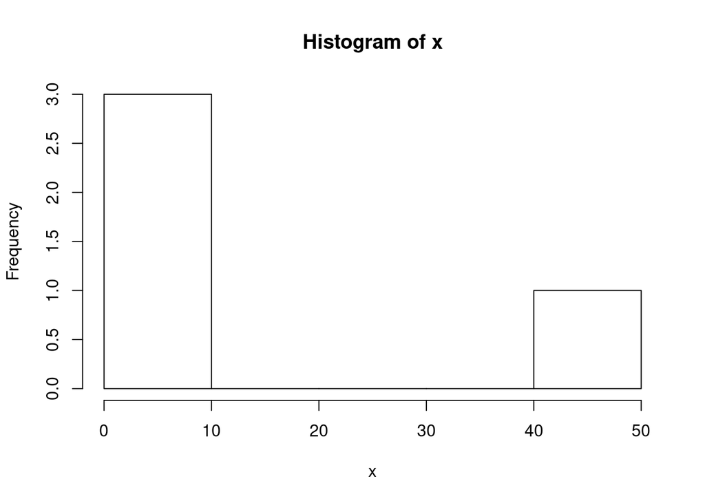

```r
hist(x)
```

takes a vector of numbers and produces a histogram, a highly structured object, with the side-effect of making a plot.

```r
ecdf(x)
```

```
## Empirical CDF
## Call: ecdf(x)
##  x[1:4] =      7,      8,     10,     45
```

produces a the empirical cumulative-density-function object.

```r
summary(x)
```

```
##    Min. 1st Qu.  Median    Mean 3rd Qu.    Max.
##    7.00    7.75    9.00   17.50   18.75   45.00
```

gives a five-number summary of numerical vectors.

# Addressing vectors

Vector of indices:

```r
x[c(2,4)]
```

```
## [1]  8 10
```

Vector of negative indices

```r
x[c(-1, -3)]
```

```
## [1]  8 10
```

Boolean vector:

```r
x[x > 9]
```

```
## [1] 45 10
```

```r
y[x > 9]
```

```
## [1] -45 -10
```

`which()` inputs a Boolean vector and returns a vector of the indices of the TRUE values:

```r
which(x > 9)
```

```
## [1] 3 4
```

```r
places <- which(x > 9)
places
```

```
## [1] 3 4
```

```r
y[places]
```

```
## [1] -45 -10
```

```r
which(x == pi)
```

```
## integer(0)
```

```r
y[which(x == pi)]
```

```
## numeric(0)
```

# Named components

You can give names to elements or components of vectors:

```r
names(x) <- c("v1","v2","v3","fred")
names(x)
```

```
## [1] "v1"   "v2"   "v3"   "fred"
```

```r
x
```

```
##   v1   v2   v3 fred
##    7    8   45   10
```

```r
x[c("fred","v1")]
```

```
## fred   v1
##   10    7
```

`names(x)` is a character vector:

```r
names(y) <- names(x)
sort(names(x))
```

```
## [1] "fred" "v1"   "v2"   "v3"
```

```r
which(names(x) == "fred")
```

```
## [1] 4
```

# Attributes

Attributes are additional layers of information that can be added to any object.

```r
attributes(x)
```

```
## $names
## [1] "v1"   "v2"   "v3"   "fred"
```

```r
y
```

```
##   v1   v2   v3 fred
##   -7   -8  -45  -10
```

```r
identical(x, -y)
```

```
## [1] TRUE
```

```r
all.equal(x, -y)
```

```
## [1] TRUE
```

```r
all(dplyr::near(x, -y))
```

```
## [1] TRUE
```

```r
names(y) <- names(x)
identical(x, -y)
```

```
## [1] TRUE
```

```r
all.equal(x, -y)
```

```
## [1] TRUE
```

```r
all(dplyr::near(x, -y))
```

```
## [1] TRUE
```

# Peculiarities of floating-point numbers

The more bits in the fraction part, the more precision.

The R floating-point data type is a `double`, a.k.a. `numeric`.

With finite precision, arithmetic on `doubles` is not the same as arithmetic on $\mathbb{R}$.

```r
0.45 == 3 * 0.15
```

```
## [1] FALSE
```

```r
0.45 - 3 * 0.15
```

```
## [1] 5.551115e-17
```

Often ignorable, but not always: - Rounding errors tend to accumulate in long calculations. - When results should be approximately 0, errors can flip signs. - When comparisons are needed withing the code. - Usually better to use `all.equal()` or `dplyr::near()` than exact comparison.

```r
(0.5 - 0.3) == (0.3 - 0.1)
```

```
## [1] FALSE
```

```r
all.equal(0.5 - 0.3, 0.3 - 0.1)
```

```
## [1] TRUE
```

```r
dplyr::near(0.5 - 0.3, 0.3 - 0.1)
```

```
## [1] TRUE
```

```r
(0.5 - 0.3) - (0.3 - 0.1)
```

```
## [1] 2.775558e-17
```

```r
as.logical((0.5 - 0.3) - (0.3 - 0.1))
```

```
## [1] TRUE
```

```r
6 * as.numeric(as.character(5 / 6))
```

```
## [1] 5
```

```r
5 / 6 == as.numeric(as.character(5 / 6))
```

```
## [1] FALSE
```

```r
5 / 6 - as.numeric(as.character(5 / 6))
```

```
## [1] 3.330669e-16
```

```r
dplyr::near(5 / 6, as.numeric(as.character(5 / 6)))
```

```
## [1] TRUE
```

# ===

An atomic vector cannot contain elements of different types. R thus coerces vectors of different types by converting the “simpler” data types to the more sophisticated ones.

```r
c(TRUE, 1L)
```

```
## [1] 1 1
```

```r
typeof(c(TRUE, 1L))
```

```
## [1] "integer"
```

```r
c(1L, 1.5)
```

```
## [1] 1.0 1.5
```

```r
typeof(c(1L, 1.5))
```

```
## [1] "double"
```

```r
c(FALSE, -1.5)
```

```
## [1]  0.0 -1.5
```

```r
typeof(c(FALSE, -1.5))
```

```
## [1] "double"
```

```r
c(1.5, "a")
```

```
## [1] "1.5" "a"
```

```r
typeof(c(1.5, "a"))
```

```
## [1] "character"
```

# A word on factors

R uses factors to represent categorical data. Factors are integer vectors that have a `levels` attribute:

```r
x <- factor(c("ab", "cd", "ab"), levels = c("ab", "cd", "ef"))
x
```

```
## [1] ab cd ab
## Levels: ab cd ef
```

```r
typeof(x)
```

```
## [1] "integer"
```

```r
attributes(x)
```

```
## $levels
## [1] "ab" "cd" "ef"
##
## $class
## [1] "factor"
```